# Delta Flight Response

Anastasia Bernat

12/16/2020

## Multinomial Flight Modeling

Flight Trials Winter 2020 were conducted from 2/17/2020 - 3/10/2020. Soapberry bugs were flight tested twice (T1 vs. T2) for multiple hours in the flight mill and observed from 8 AM to (5-8 PM) each day. I used multicategorical, nominal modeling (multinom) to analyze how sex and host plant as well as changes in mass and egg-laying changed a soapberry bug’s flight response between trials.

### Delta Flight Response (T1 vs. T2)

Introduction

Clean the Data

Flight Case ~ Mass Diff

Flight Case ~ Mass Per

Flight Case ~ Mass Diff or Mass Perc + Sex

Flight Case ~ Mass Diff or Mass Perc + Sex + Host Plant

Flight Case ~ Mass Diff or Mass Perc + Sex + Wing2Body

Females Only

- Flew Diff ~ Mass Diff + Egg Case
- Flew Diff ~ Madd Diff + Egg Case + Wing2Body

#### Introduction

Graphs I generated below illustrate how changes in mass (more specifically % mass) or egg-laying led to changes in flight response. To generate these graphs, I ran multicategorical regressions to model the probability of different flight delta cases due to sex, host plant, and changes in mass or egg-laying. Changes in speed and distance as a result of changes in mass or egg-laying were not analyzed here but rather in a separate script.

To perform these analyses, a new variable will be created called “flight_case” which calculates the flight response differences between T1 and T2. Here is a formula and key describing each flight case event and encoding:

**Formula** *: flight case = response in* $T_2$ *- response in* $T_1$

| Delta Flight Response Key Event | Delta Flight Response Key Encoding |
| --- | --- |
| flew in both trials | 2 |
| flew in T2 only | 1 |
| flew in neither trials | 0 |
| flew in T1 only | -1 |

Since the outcomes (or response variables) were no longer binomial, I used multicategorical logit models (refer to Chapter 6 of *An Introduction to Categorical Data Analysis, Second Edition* by Alan Agresti). Below I’ve written out notes on performing these analyses.

**What we are interested in is a multicategorical, nominal response variable.** When the response variable is nominal, there is no natural order among the response variable categories (unordered categories). When the response variable is multicategorical, its multicategory models assume that the counts in the categories of $Y$ have a *multinomial distribution*.

Let J = number of categories for $Y$.

$\pi_1,...\pi_J$ = the response probabilities where $\sum_j \pi_j = 1$.

With $n$ independent observations, the probability distribution for the number of outcomes of the J types is the multinomial. It specifies the probability for each possible way the $n$ observations can fall in the J categories. Multicategory logit models simultaneously use all pairs of categories by specifying the odds of outcome in one category instead of another.

Logit models for nominal response variables pair each category with a baseline category. The choice of the baseline category is arbitrary. When the last category (J) is the baseline, the **baseline-category logits** are

$\log (\frac{\pi_j}{\pi_J}), j = 1, ..., J - 1$.

Given that the response falls in category j or category J, this is the log odds that the response is j. **For J = 3**, for instance, the model uses $\log(\pi_1/\pi_3)$ and $\log(\pi_2/\pi_3)$. The baseline-category logit model with a predictor x is

$\log \frac{\pi_j}{\pi_J} = \alpha_J + \beta_j x, j = 1, ..., J - 1$

The model has J - 1 equations, with separate parameters for each. **The effects vary according to the category paired with the baseline**. When J = 2, this model simplifies to a single equation for $\log(\pi_1/\pi_2) = logit(\pi_1)$, resulting in ordinary logistic regression for binary responses.

So how do these pair of categories determine equations for all other pairs of categories? Here is an arbitrary pair of categories a and b that follows the general equation above,

$\log (\frac{\pi_a}{\pi_b}) = \log ( \frac{\pi_a/pi_J}{\pi_b/pi_J}) = \log (\frac{\pi_a}{\pi_J}) - \log (\frac{\pi_b}{\pi_J})$

$= (\alpha_a + \beta_a x) - (\alpha_b + \beta_b x)$

$= (\alpha_a - \alpha_b) + (\beta_a - \beta_b) x$

So, the equation for categories a and b has the form $\alpha + \beta x$ with intercept parameter $\alpha = (\alpha_a - \alpha_b)$ and with slope parameter $\beta = (\beta_a - \beta_b)$.

Let’s apply it to our data now:

#### Cleaning the Data

```r
output_col = FALSE # Change to TRUE if working in Base R or RStudio; FALSE if generating an HTML
source("src/clean_flight_data.R") # Loads and cleans data
source("src/regression_output.R") # Cleans regression outputs; prints in color or black & white
source("src/center_flight_data.R") # Re-centers data
source("src/get_warnings.R")

data <- read_flight_data("data/all_flight_data-Winter2020.csv")
data_all <- data[[1]]
data_tested <- data[[2]]
source("src/unique_flight_data.R")
d <- create_delta_data(data_tested)
```

```r
colnames(d)[c(1:2,5,66:68,71:73)]
```

```
## [1] "ID"          "sex"         "host_plant"  "egg_diff"    "mass_diff"
## [6] "flew_diff"   "mass_per"    "flight_case" "egg_case"
```

#### Age Effect

Age also plays a role in this dataset, but age was unknown because the soapberry bugs were field collected.

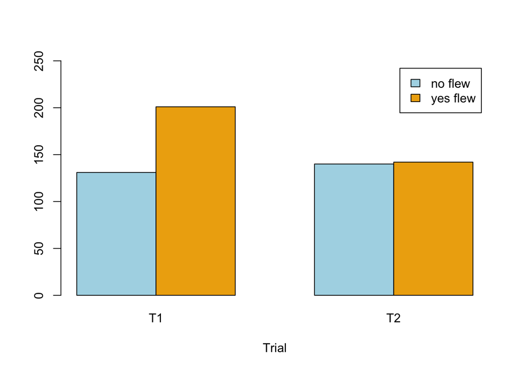

#### Modeling

Below I used the **multinom function** from the **nnet package** to estimate a *multinomial logistic regression* model. There are other functions in other R packages capable of multinomial regression. I chose the multinom function because it does not require the data to be reshaped (as the mlogit package does) and to mirror the example code found in Hilbe’s *Logistic Regression Models*.

First, I chose the baseline by specifying the level using relevel function. Then, I ran our model using multinom. The multinom package does not include p-value calculations for the regression coefficients, so I calculated *P* using **Wald tests (i.e. z-tests)**.

Finally, I considered **mass difference** as my predictor variable where a (+) sign means the bug gained mass between trials and a (-) sign means the bug lost mass between trials.

| Delta Mass Key Event | Delta Mass Key Sign |
| --- | --- |
| gained mass from T1 to T2 | pos |
| no mass change between trails | 0 |
| lost mass from T1 to T2 | neg |

**Baseline**

```r
df <- d %>%
  filter(!is.na(mass_diff), !is.na(flight_case))

df <- df[with(df, order(mass_diff)),]
n_trials = nrow(df)

df$flight_case <- relevel(as.factor(df$flight_case), ref = "2")
```

**Null model**

```r
null <- multinom(flight_case ~ 1, data = df)
```

**Multinom model: flight_case ~ mass_diff**

```r
model <- multinom(flight_case ~ mass_diff, data = df)
model_table = calculate_P(model)
```

```
##
##  AIC:  628.8786
##    (Intercept)  Estimate DF Std. Err.      z   wald P > |z|
## -1      -1.194    44.620  6    14.080  3.169 10.043   0.002
## 0       -0.421   -24.940  6    12.653 -1.971  3.885   0.049
## 1       -2.550   -17.175  6    28.833 -0.596  0.355   0.551
```

```r
anova(null, model, test="Chisq") # adding mass_diff improves fit
```

```
## Likelihood ratio tests of Multinomial Models
##
## Response: flight_case
##       Model Resid. df Resid. Dev   Test    Df LR stat.      Pr(Chi)
## 1         1       831   638.5394
## 2 mass_diff       828   616.8786 1 vs 2     3 21.66072 7.674083e-05
```

**Which multinomial model equations are significant:**

```r
get_significant_models()
```

```
## Baseline is:  -1
##  Equation is 1   P is 0.07500189
## Baseline is:  0
##  Equation is 1   P is 0.8170477
## Baseline is:  1
##  Equation is 0   P is 0.6675451
##  Equation is -1  P is 0.06789213
##  Equation is 2   P is 0.6771318
## Baseline is:  2
##  Equation is 1   P is 0.5514031
##
## Baselines are the rows and the equations are the columns.
##       -1     0     1     2
## -1    NA 0.000 0.075 0.002
## 0  0.000    NA 0.817 0.045
## 1  0.068 0.668    NA 0.677
## 2  0.002 0.049 0.551    NA
```

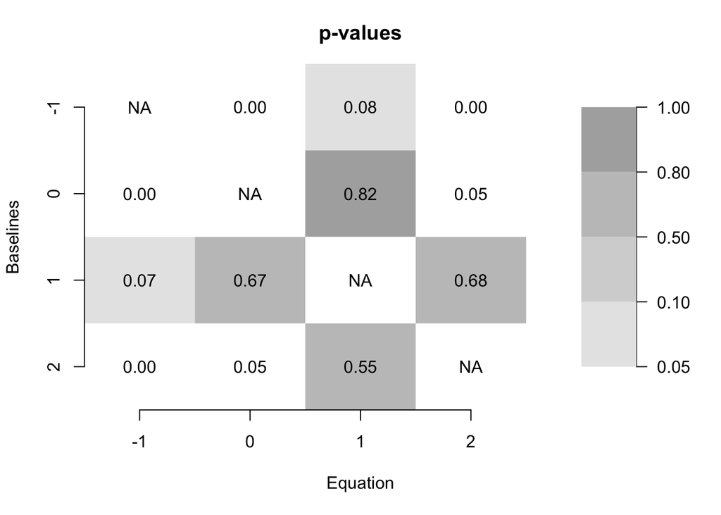

```
##              -1            0          1           2
## -1           NA 3.812004e-05 0.07500189 0.002083251
## 0  2.667617e-05           NA 0.81704774 0.045456643
## 1  6.789213e-02 6.675451e-01         NA 0.677131844
## 2  1.529058e-03 4.872028e-02 0.55140311          NA
```

**The multinomial (ML) prediction equations are:**

```r
prediction_equations(model_table)
```

```
## [1] "log(pi_-1 / pi_1) = -0.77 + 69.56 Mass Change     Flew in T1, rather than T2"
## [2] "log(pi_2 / pi_-1) = -1.36 + -61.79 Mass Change     Flew in both, rather than T1"
## [3] "log(pi_2 / pi_1) = -2.13 + 7.76 Mass Change     Flew in both, rather than T2"
```

N

Model

P

278

Flew in T1 only rather than T2 only = 1.36 + 62.51 Mass Change

278

Flew in both rather than T1 only = 1.19 - 43.88 Mass Change

278

Flew in both rather than T2 only = 2.55 + 18.63 Mass Change

**Estimated Odds**

For bugs of mass_diff x + 1 * (1/50 g or 0.02 g), the estimated odds that the bug flew in T1 rather than T2 equals

```r
exp(62.51/50)
```

```
## [1] 3.491041
```

times the estimated odds at mass_diff x (g). As gain mass, then less likely to fly again.

For bugs of mass_diff x + 1/50 (0.02) g, the estimated odds that the bug flew twice rather than only in T1 equals

```r
exp(-43.88/50)
```

```
## [1] 0.4157796
```

times the estimated odds at mass_diff x (g). Same idea - as gain mass, then less likely to fly again.

For bugs of mass_diff x + 1/50 (0.02) g, the estimated odds that the bug flew twice rather than only in T2 equals

```r
exp(18.63/50)
```

```
## [1] 1.451504
```

times the estimated odds at mass_diff x (g). As gain mass, then more likely to fly twice rather than fly only in T2. So the case of flying twice is more likely than only flying in T2 more so because only flying in T2 is a very rare case if you gain mass. So flying twice is more likely when a bug gains mass but not necessarily *most likely*. What is most likely is flying only in T1 if a bug gains mass

```r
exp(coef(model)/50) # this compares to not flying, the baseline
```

```
##    (Intercept) mass_diff
## -1   0.9763954 2.4409702
## 0    0.9916226 0.6072609
## 1    0.9502788 0.7092857
```

**Predicted probabilities**

You can also use predicted probabilities to help you understand the model. **The multicategory logit model has an alternative expression in terms of the response probabilities**. This is

$\pi_j = \frac{e^{\alpha_j + \beta_j x}}{\sum_he^{\alpha_h + \beta_h x}}, j=1,...,J$

The denominator is the same for each probability, and the numerators for various j sum to the denominator where $\sum_j \pi_j = 1$. The parameters ($\alpha$ and$\beta$) equal zero for whichever category is the baseline in the logit expressions. So these would be the equations for the model above:

$\hat{\pi_{-1}} = \frac{e^{-1.77 + 69.21 x}}{1 + e^{-1.77 + 69.21 x} + e^{-2.13 - 6.70 x} + e^{0.42 + 25.33 x}}, j=1,...,J$

$\hat{\pi_1} = \frac{e^{-2.13 - 6.70 x}}{1 + e^{-1.77 + 69.21 x} + e^{-2.13 - 6.70 x} + e^{0.42 + 25.33 x}}, j=1,...,J$

$\hat{\pi_2} = \frac{e^{0.42 + 25.33 x}}{1 + e^{-1.77 + 69.21 x} + e^{-2.13 - 6.70 x} + e^{0.42 + 25.33 x}}, j=1,...,J$

$\hat{\pi_0} = \frac{e^{0 + 0 x} = 1}{1 + e^{-1.77 + 69.21 x} + e^{-2.13 - 6.70 x} + e^{0.42 + 25.33 x}}, j=1,...,J$

x = mass_diff, which can give you the estimated probabilities.

You can calculate these predicted probabilities for each of our outcome levels using the fitted function. You can start by generating the predicted probabilities for the observations in our dataset and viewing the first few rows. Then, you can plot them.

```r
head(pp <- fitted(model))
```

```
##           2         -1         0          1
## 1 0.3098956 0.01260337 0.6250904 0.05241057
## 2 0.3398496 0.01806453 0.5902374 0.05184854
## 3 0.3448838 0.01916862 0.5842269 0.05172061
## 4 0.3650173 0.02425181 0.5596253 0.05110561
## 5 0.3750272 0.02724267 0.5469960 0.05073411
## 6 0.3849532 0.03057392 0.5341544 0.05031845
```

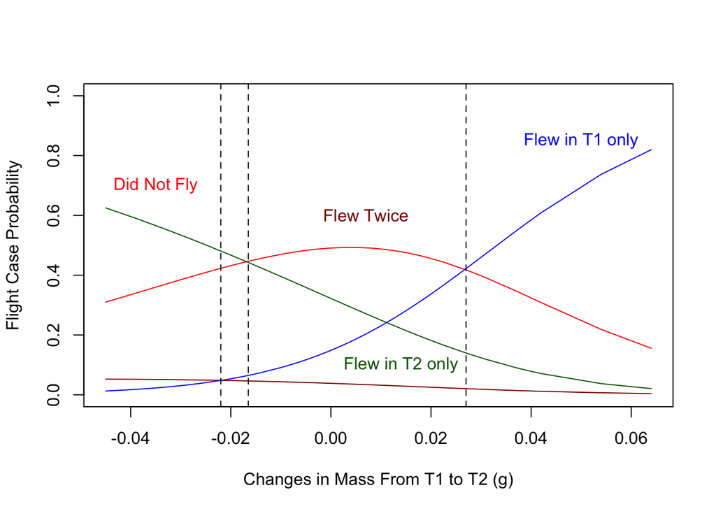

**Multinom model: flight case ~ mass_per**

**Re-order**

```r
df <- df[with(df, order(mass_per)),]
```

```r
model <- multinom(flight_case ~ mass_per, data = df)
model_table = calculate_P(model)
```

```
##
##  AIC:  625.9695
##    (Intercept)  Estimate DF Std. Err.      z  wald P > |z|
## -1      -1.253     0.024  6     0.008  3.015 9.092   0.003
## 0       -0.344    -0.021  6     0.008 -2.493 6.214   0.013
## 1       -2.474    -0.020  6     0.019 -1.016 1.033   0.310
```

**The multinomial (ML) prediction equations are:**

```r
gsub("Mass Change",  "Mass Percent Change", prediction_equations(model_table))
```

```
## [1] "log(pi_-1 / pi_1) = -0.91 + 0.04 Mass Percent Change     Flew in T1, rather than T2"
## [2] "log(pi_2 / pi_-1) = -1.22 + -0.04 Mass Percent Change     Flew in both, rather than T1"
## [3] "log(pi_2 / pi_1) = -2.13 + 0 Mass Percent Change     Flew in both, rather than T2"
```

| N | Model |
| --- | --- |
| 278 | Flew in T1 only rather than T2 only = 1.22 + 0.04 Mass % |
| 278 | Flew in both rather than T1 only = 1.25 - 0.02 Mass % |
| 278 | Flew in both rather than T2 only = 2.48 + 0.02 Mass % |

**Estimated Odds**

For bugs of mass_perc x + 20%*(0.04) the estimated odds that bug flew in T1 rather than T2 equals

```r
exp(0.04*20)
```

```
## [1] 2.225541
```

times the estimated odds at mass_perc x (%). So for every 20% increase in a bug’s original mass, the bug is 2.23 times more likely to fly only in T1. That makes sense because the odds of flying in T2 only are very low to begin with.

For bugs of mass_perc x + 40%*(-0.02), the estimated odds that the bug flew twice instead of only in T1 equals

```r
exp(40*-0.02) # 2.5 times less likely to fly twice if gain mass
```

```
## [1] 0.449329
```

```r
exp(-40*-0.02) # 2.5 times more likely to fly twice if loose mass
```

```
## [1] 2.225541
```

times the estimated odds at mass_perc x (%). Similar message - for every 40% increase in a bug’s original mass, the bug was 2.23 times more likely to fly only in T1 rather than fly twice. Although, when a bug looses 40% of original mass then becomes more likely to fly twice then only once.

```r
exp(coef(model)*20) # this compares to no fly, the baseline # gain large % mass
```

```
##     (Intercept)  mass_per
## -1 1.302365e-11 1.6020675
## 0  1.034432e-03 0.6631352
## 1  3.262176e-22 0.6736718
```

```r
exp(coef(model)*5) # gain small % mass
```

```
##     (Intercept)  mass_per
## -1 1.899692e-03 1.1250458
## 0  1.793393e-01 0.9024030
## 1  4.249882e-06 0.9059664
```

```r
exp(coef(model)*-5) # loose small % mass
```

```
##     (Intercept)  mass_per
## -1 5.264011e+02 0.8888527
## 0  5.576022e+00 1.1081524
## 1  2.353007e+05 1.1037937
```

```r
exp(coef(model)*-20) # loose large % mass
```

```
##     (Intercept)  mass_per
## -1 7.678339e+10 0.6241934
## 0  9.667137e+02 1.5079880
## 1  3.065438e+21 1.4844023
```

```r
head(pp <- fitted(model))
```

```
##           2         -1         0          1
## 1 0.3566214 0.04279653 0.5384275 0.06215456
## 2 0.3590410 0.04370246 0.5354198 0.06183669
## 3 0.3642823 0.04572706 0.5288498 0.06114084
## 4 0.3664440 0.04658780 0.5261173 0.06085085
## 5 0.3880112 0.05609586 0.4980412 0.05785174
## 6 0.3904553 0.05729083 0.4947553 0.05749852
```

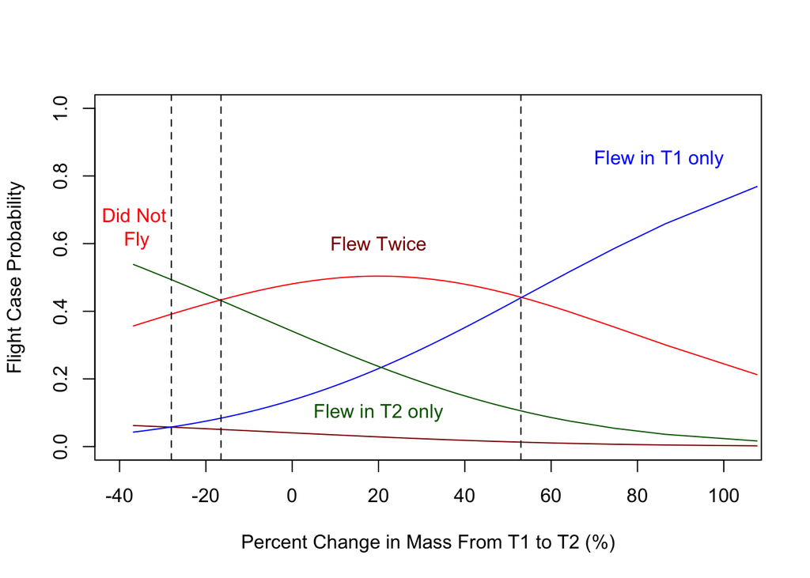

For more on multinomial plotting for when have more than 1 predictor variables see the following: https://stats.idre.ucla.edu/r/dae/multinomial-logistic-regression/

#### Now let’s compare some models

**First: flight_case, mass_diff, and sex**

```r
df <- df[with(df, order(mass_diff)),]
```

```r
data <- data.frame(R = df$flight_case,
         A = df$mass_diff,
         B = df$sex_c)
source("src/compare_models.R")
model_comparisonsAIC("src/generic multinomial models- multinom 1RF + 2 FF.R")
```

```
##        [,1]      [,2]
## AICs   589.9106  593.6839
## models 3         4
## probs  0.8681634 0.1315939
##
## m3   multinom(formula = R ~ A + B, data = data, trace = FALSE)
## m4   multinom(formula = R ~ A * B, data = data, trace = FALSE)
```

```r
anova(m3, m4, test="Chisq") # Adding A*B does not improve fit
```

```
## Likelihood ratio tests of Multinomial Models
##
## Response: R
##   Model Resid. df Resid. Dev   Test    Df LR stat.   Pr(Chi)
## 1 A + B       825   571.9106
## 2 A * B       822   569.6839 1 vs 2     3 2.226681 0.5267122
```

```r
delta_mass_model <- multinom(flight_case ~ mass_diff + sex_c, data = df)
model_table = calculate_P2(delta_mass_model, "mass_diff", "sex_c")
```

```
##
##  AIC:  589.9106
##    (Intercept) mass_diff  sex_c DF    SE1    SE2     z1     z2 ML wald sex wald
## -1      -1.160    50.205  0.103  9 17.047  0.216  2.945  0.478   8.673    0.228
## 0       -0.208   -17.726  0.883  9 12.717  0.157 -1.394  5.630   1.943   31.692
## 1       -7.194   -34.995 -4.898  9 65.807 40.198 -0.532 -0.122   0.283    0.015
##    P1 > |z| P2 > |z|
## -1    0.003    0.633
## 0     0.163    0.000
## 1     0.595    0.903
```

```r
prediction_equations2(model_table, " Mass Change", " Sex ")
```

```
## [1] "Where F = 1"
```

```
## [1] "log(pi_-1 / pi_1) = -0.95 + 67.93 Mass Change + -0.78 Sex      Flew in T1, rather than T2"
## [2] "log(pi_2 / pi_-1) = -6.03 + -85.2 Mass Change + -5 Sex      Flew in both, rather than T1"
## [3] "log(pi_2 / pi_1) = -6.99 + -17.27 Mass Change + -5.78 Sex      Flew in both, rather than T2"
```

| N | Model |
| --- | --- |
| 278 | Flew in T1 only rather than T2 only = 16.5 + 98.29 Mass Change + 15.49 Sex |
| 278 | Flew in both rather than T1 only = 1.25 - 50.49 Mass Change - 0.1 Sex |
| 278 | Flew in both rather than T2 only = 17.67 + 47.8 Mass Change + 15.39 Sex |

**Second: flight_case, mass_per, and sex**

```r
df <- df[with(df, order(mass_per)),]
```

```r
data <- data.frame(R = df$flight_case,
         A = df$mass_per,
         B = df$sex_c)
source("src/compare_models.R")
model_comparisonsAIC("src/generic multinomial models- multinom 1RF + 2 FF.R")
```

```
##        [,1]      [,2]
## AICs   587.5608  593.4212
## models 3         4
## probs  0.9492424 0.05067561
##
## m3   multinom(formula = R ~ A + B, data = data, trace = FALSE)
## m4   multinom(formula = R ~ A * B, data = data, trace = FALSE)
```

```r
anova(m3, m4, test="Chisq") # Adding A*B does not improve fit
```

```
## Likelihood ratio tests of Multinomial Models
##
## Response: R
##   Model Resid. df Resid. Dev   Test    Df  LR stat.   Pr(Chi)
## 1 A + B       825   569.5608
## 2 A * B       822   569.4212 1 vs 2     3 0.1395612 0.9866999
```

```r
delta_mass_model <- multinom(flight_case ~ mass_per + sex_c, data = df)
model_table = calculate_P2(delta_mass_model, "mass_per", "sex_c")
```

```
##
##  AIC:  587.5608
##    (Intercept) mass_per  sex_c DF   SE1   SE2     z1      z2 ML wald sex wald
## -1      -1.139    0.023  0.210  9 0.008 0.197  2.764   1.067   7.638    1.139
## 0       -0.124   -0.019  0.902  9 0.008 0.159 -2.333   5.689   5.444   32.360
## 1       -6.959   -0.029 -4.738  9 0.026 0.170 -1.113 -27.906   1.239  778.724
##    P1 > |z| P2 > |z|
## -1    0.006    0.286
## 0     0.020    0.000
## 1     0.266    0.000
```

```r
prediction_equations2(model_table, " Mass Percent Change", " Sex ")
```

```
## [1] "Where F = 1"
```

```
## [1] "log(pi_-1 / pi_1) = -1.02 + 0.04 Mass Percent Change + -0.69 Sex      Flew in T1, rather than T2"
## [2] "log(pi_2 / pi_-1) = -5.82 + -0.05 Mass Percent Change + -4.95 Sex      Flew in both, rather than T1"
## [3] "log(pi_2 / pi_1) = -6.83 + -0.01 Mass Percent Change + -5.64 Sex      Flew in both, rather than T2"
```

| N | Model |
| --- | --- |
| 278 | Flew in T1 only rather than T2 only = 5.81 + 0.05 Mass % + 4.93 Sex |
| 278 | Flew in both rather than T1 only = 1.14 - 0.02 Mass % - 0.21 Sex |
| 278 | Flew in both rather than T2 only = 6.94 + 0.03 Mass % + 4.72 Sex |

**Estimated Odds**

**For males:**

For bugs of mass_perc x + 20%*(0.05), the estimated odds that bug flew in T1 rather than T2 equals

```r
exp(0.05*20)
```

```
## [1] 2.718282
```

times the estimated odds at mass_perc x (%). So for every 20% increase in a bug’s original mass, the bug was 2.72 times more likely to fly only in T1. That makes sense because the odds of flying in T2 only are very low to begin with.

For bugs of mass_perc x + 20*(-0.02%), the estimated odds that the bug flew twice instead of only in T1 equals

```r
exp(20*-0.02) # 20 times less likely to fly twice if gain mass
```

```
## [1] 0.67032
```

```r
exp(-20*-0.02) # 20 times more likely to fly twice if loose mass
```

```
## [1] 1.491825
```

times the estimated odds at mass_perc x (%). Similar message - for every 20% increase in a bug’s original mass, the bug was 1.5 times more likely to fly only in T1. So, when a bug starts loosing mass it becomes more likely to fly twice then only once.

**For females:**

For bugs of mass_perc x + 20%*(0.05), the estimated odds that bug flew in T1 rather than T2 equals

```r
exp(0.05*20 + 4.93)
```

```
## [1] 376.1545
```

times the estimated odds at mass_perc x (%). So for every 20% increase in a bug’s original mass, the bug was **376** times more likely to fly only in T1. Crazy! It doesn’t take much for a female to only fly once.

For bugs of mass_perc x + 20%*(0.05), the estimated odds that bug flew in both trials rather than T1 equals

```r
exp(-0.02*20 - 0.21)
```

```
## [1] 0.5433509
```

```r
exp(-0.02*-40 - 0.21)
```

```
## [1] 1.803988
```

times the estimated odds at mass_perc x (%). So half as likely to fly in both trials if gain mass. Would need to loose a lot of mass (40) to be almost twice as likely (1.8) to fly in both trials.

```r
exp(coef(delta_mass_model)*20) # this compares to no fly, the baseline # gain large % mass
```

```
##     (Intercept)  mass_per        sex_c
## -1 1.275485e-10 1.5886521 6.649445e+01
## 0  8.424627e-02 0.6786544 6.886699e+07
## 1  3.622174e-61 0.5635923 7.079192e-42
```

```r
exp(coef(delta_mass_model)*5) # gain small % mass
```

```
##     (Intercept)  mass_per        sex_c
## -1 3.360616e-03 1.1226831 2.855593e+00
## 0  5.387505e-01 0.9076369 9.109673e+01
## 1  7.757867e-16 0.8664455 5.158173e-11
```

```r
exp(coef(delta_mass_model)*-5) # loose small % mass
```

```
##     (Intercept)  mass_per        sex_c
## -1 2.975645e+02 0.8907233 3.501899e-01
## 0  1.856147e+00 1.1017621 1.097734e-02
## 1  1.289014e+15 1.1541407 1.938671e+10
```

```r
exp(coef(delta_mass_model)*-20) # loose large % mass
```

```
##     (Intercept)  mass_per        sex_c
## -1 7.840152e+09 0.6294644 1.503885e-02
## 0  1.186996e+01 1.4735040 1.452075e-08
## 1  2.760773e+60 1.7743323 1.412591e+41
```

- If F and gain a lot of mass then most likely to fly only in T1 rather than none.
- If F and loose mass then most likely to not fly in either trial.

**Predicted Probabilities**

```r
head(pp <- fitted(delta_mass_model))
```

```
##           2         -1         0            1
## 1 0.1781381 0.03001669 0.7918409 4.259268e-06
## 2 0.1797132 0.03070694 0.7895757 4.223401e-06
## 3 0.1831573 0.03225639 0.7845821 4.146057e-06
## 4 0.1845911 0.03291796 0.7824868 4.114284e-06
## 5 0.1993583 0.04033504 0.7603028 3.800137e-06
## 6 0.2010893 0.04128094 0.7576260 3.764731e-06
```

```r
df$index = 1:nrow(df)
females = df %>%
  filter(sex=="F")
males = df %>%
  filter(sex=="M")
Frows = females$index
Mrows = males$index
```

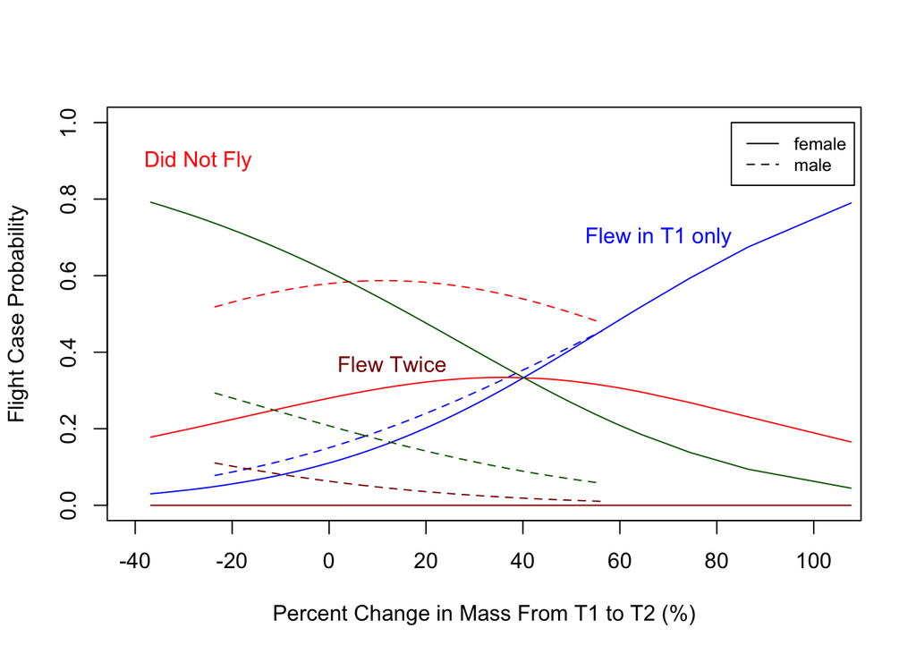

No females flew in T2 only.

#### Adding Host Plant

```r
df <- df[with(df, order(mass_diff)),]
```

```r
data <- data.frame(R = df$flight_case,
         A = df$mass_diff,
         B = df$sex_c,
         C = df$host_c)
source("src/compare_models.R")
model_comparisonsAIC("src/generic multinomial models- multinom 1RF + 3 FF.R")
```

```
##        [,1]      [,2]      [,3]      [,4]      [,5]       [,6]
## AICs   589.9106  592.2332  593.0435  593.6839  594.0337   594.5184
## models 4         12        13        8         7          15
## probs  0.5013977 0.1569748 0.1046851 0.0760005 0.06380515 0.05007281
##
## m4   multinom(formula = R ~ A + B, data = data, trace = FALSE)
## m12  multinom(formula = R ~ A * C + B, data = data, trace = FALSE)
## m13  multinom(formula = R ~ B * C + A, data = data, trace = FALSE)
## m8   multinom(formula = R ~ A * B, data = data, trace = FALSE)
## m7   multinom(formula = R ~ A + B + C, data = data, trace = FALSE)
## m15  multinom(formula = R ~ A * C + C * B, data = data, trace = FALSE)
```

```r
anova(m4, m7, test="Chisq") # Adding C (host plant) does not improve fit
```

```
## Likelihood ratio tests of Multinomial Models
##
## Response: R
##       Model Resid. df Resid. Dev   Test    Df LR stat.  Pr(Chi)
## 1     A + B       825   571.9106
## 2 A + B + C       822   570.0337 1 vs 2     3 1.876869 0.598352
```

Host plant is not significant.

#### Wing2Body

```r
df <- df[with(df, order(mass_per)),]
```

```r
data <- data.frame(R = df$flight_case,
         A = df$mass_per,
         B = df$sex_c,
         C = df$wing2body)
source("src/compare_models.R")
model_comparisonsAIC("src/generic multinomial models- multinom 1RF + 3 FF.R")
```

```
##        [,1]      [,2]      [,3]
## AICs   582.2895  585.1053  587.3905
## models 7         12        13
## probs  0.6726832 0.1645762 0.05249947
##
## m7   multinom(formula = R ~ A + B + C, data = data, trace = FALSE)
## m12  multinom(formula = R ~ A * C + B, data = data, trace = FALSE)
## m13  multinom(formula = R ~ B * C + A, data = data, trace = FALSE)
```

```r
anova(m7, m12, test="Chisq") # adding A*C does not improve fit
```

```
## Likelihood ratio tests of Multinomial Models
##
## Response: R
##       Model Resid. df Resid. Dev   Test    Df LR stat.  Pr(Chi)
## 1 A + B + C       822   558.2895
## 2 A * C + B       819   555.1053 1 vs 2     3 3.184198 0.364088
```

```r
anova(m7, m13, test="Chisq") # Adding B*C does not improve fit
```

```
## Likelihood ratio tests of Multinomial Models
##
## Response: R
##       Model Resid. df Resid. Dev   Test    Df  LR stat.   Pr(Chi)
## 1 A + B + C       822   558.2895
## 2 B * C + A       819   557.3905 1 vs 2     3 0.8990572 0.8256553
```

```r
model <- multinom(flight_case ~ mass_per + sex_c + wing2body, data = df)
# compute p-values using Wald tests (i.e. z-tests)
s <- summary(model)
z <- s$coefficients/s$standard.errors
wald <- z^2
p <- (1 - pnorm(abs(z), 0, 1)) * 2

# summary table (similar to lm, glm, or lmer function)
model_table <- cbind(s$coefficients, c(s$edf, s$edf), s$standard.errors[,2:4], z[,2:4], wald[,2:4], p[,2:4])
colnames(model_table) <- c("(Intercept)", "mass %", "sex","wing2body","DF",
                            "SE1", "SE2", "SE3", "z1", "z2", "z3",
                            "wald2","wald1", "wald3", "P1>|z|", "P2>|z|", "P3>|z|")
cat("\n", "AIC: ", s$AIC, "\n")
```

```
##
##  AIC:  582.2895
```

```r
print(round(model_table,3))
```

```
##    (Intercept) mass %     sex wing2body DF   SE1   SE2    SE3     z1     z2
## -1       2.929  0.023   0.183    -5.657 12 0.008 0.203 10.819  2.778  0.899
## 0       20.974 -0.018   0.756   -29.476 12 0.008 0.166  9.767 -2.131  4.563
## 1        6.493 -0.024 -14.045   -31.608 12 0.025 6.776 18.914 -0.969 -2.073
##        z3 wald2  wald1 wald3 P1>|z| P2>|z| P3>|z|
## -1 -0.523 7.718  0.808 0.273  0.005  0.369  0.601
## 0  -3.018 4.541 20.817 9.107  0.033  0.000  0.003
## 1  -1.671 0.939  4.297 2.793  0.333  0.038  0.095
```

Signal of flying in only T2 is weak, which is probably why the equation in the model was not significant. It does not differ much from not flying at all.

**Predicted Probabilities**

```r
head(pp <- fitted(model))
```

```
##           2         -1         0            1
## 1 0.2187808 0.03592460 0.7452946 3.923423e-14
## 2 0.1585237 0.02861202 0.8128643 4.393985e-14
## 3 0.2622751 0.04318267 0.6945422 3.555294e-14
## 4 0.1663987 0.03118379 0.8024175 4.277587e-14
## 5 0.1928336 0.04029237 0.7668740 3.920329e-14
## 6 0.1718237 0.03754663 0.7906297 4.071498e-14
```

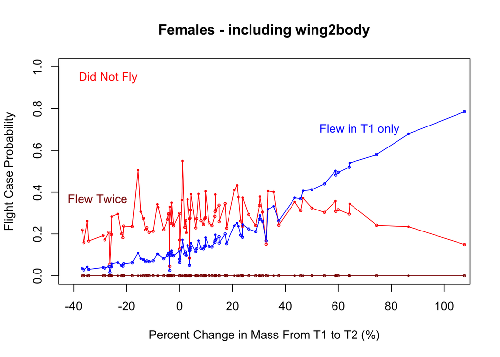

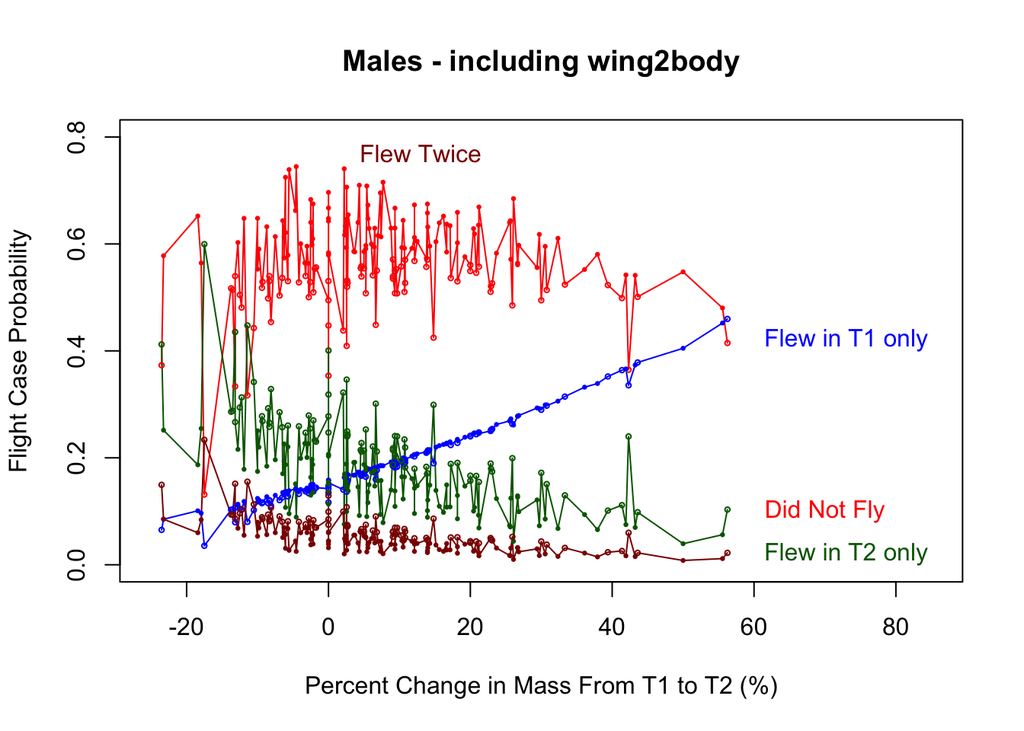

Amazing to see what a clear impact wing2body ratio has for whether bugs are more likely to fly twice or not fly at all. Those with wing2body ratios above the mean wing2body ratio appear to be more likely to fly twice and less likely to not fly. This is true across females and males.

#### Females only

**Baseline**

```r
df <- d %>%
  filter(!is.na(egg_diff), !is.na(mass_diff), !is.na(flew_diff), sex_c == 1)

df <- df[with(df, order(mass_diff)),]

n_tfemales = nrow(df)

df$flight_case <- relevel(as.factor(df$flight_case), ref = "0")
```

**Barplot**

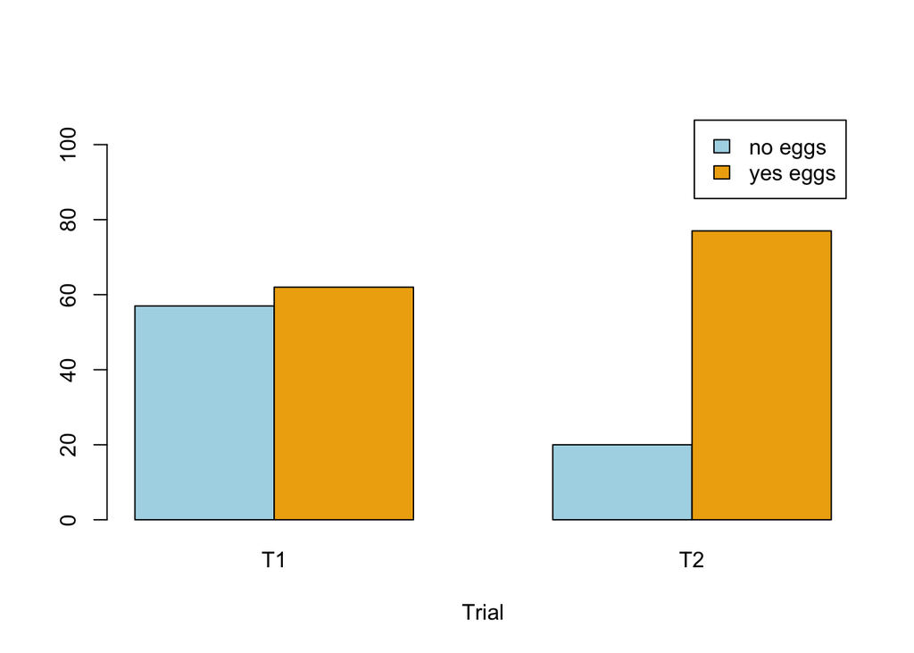

**Egg Case**

| Delta Egg Response Key Event | Delta Egg Response Key Encoding |
| --- | --- |
| laid eggs in both trials | 2 |
| laid eggs in T2 only | 1 |
| laid eggs in neither trials | 0 |
| laid eggs in T1 only | -1 |

**Baseline**

```r
df <- d %>%
  filter(!is.na(egg_case), !is.na(mass_diff), !is.na(flew_diff), sex_c == 1)

df <- df[with(df, order(mass_diff)),]

n_tfemales = nrow(df)

df$flight_case <- relevel(as.factor(df$flight_case), ref = "0")
```

**Null model**

```r
df$flight_case = droplevels(df$flight_case) # no female bug only flew in T2
null <- multinom(flight_case ~ 1, data = df)
```

**Multinom model: flew_diff ~ egg_case**

```r
model <- multinom(flight_case ~ egg_case, data = df)
model_table = calculate_P(model)
```

```
##
##  AIC:  176.2298
##    (Intercept)  Estimate DF Std. Err.      z   wald P > |z|
## -1      -0.194    -0.656  4     0.345 -1.902  3.616   0.057
## 2        0.697    -1.189  4     0.314 -3.782 14.306   0.000
```

```r
anova(null, model, test="Chisq") # adding egg_case improves fit
```

```
## Likelihood ratio tests of Multinomial Models
##
## Response: flight_case
##      Model Resid. df Resid. Dev   Test    Df LR stat.      Pr(Chi)
## 1        1       184   186.1109
## 2 egg_case       182   168.2298 1 vs 2     2 17.88112 0.0001309677
```

**Comparing models: adding host**

Adding host with egg_diff and mass_diff

| Host Plant Key Host | Host Plant Key Encoding |
| --- | --- |
| Golden Rain Tree (GRT) | 1 |
| Balloon Vine (BV) | -1 |

```r
data <- data.frame(R = df$flight_case,
         A = df$egg_case,
         B = df$mass_diff,
         C = df$host_c)
source("src/compare_models.R")
model_comparisonsAIC("src/generic multinomial models- multinom 1RF + 3 FF.R")
```

```
##        [,1]      [,2]      [,3]      [,4]       [,5]
## AICs   165.1826  166.6029  167.0497  167.9211   167.9513
## models 7         13        4         11         16
## probs  0.3572256 0.1756085 0.1404487 0.09084268 0.08948043
##
## m7   multinom(formula = R ~ A + B + C, data = data, trace = FALSE)
## m13  multinom(formula = R ~ B * C + A, data = data, trace = FALSE)
## m4   multinom(formula = R ~ A + B, data = data, trace = FALSE)
## m11  multinom(formula = R ~ A * B + C, data = data, trace = FALSE)
## m16  multinom(formula = R ~ B * C + A * B, data = data, trace = FALSE)
```

```r
anova(m4, m7, test="Chisq") # Adding C does not improve fit
```

```
## Likelihood ratio tests of Multinomial Models
##
## Response: R
##       Model Resid. df Resid. Dev   Test    Df LR stat.    Pr(Chi)
## 1     A + B       180   155.0497
## 2 A + B + C       178   149.1826 1 vs 2     2  5.86705 0.05320915
```

```r
anova(m7, m13, test="Chisq") # Adding  mass_diff*host does not improve fit
```

```
## Likelihood ratio tests of Multinomial Models
##
## Response: R
##       Model Resid. df Resid. Dev   Test    Df LR stat.   Pr(Chi)
## 1 A + B + C       178   149.1826
## 2 B * C + A       176   146.6029 1 vs 2     2 2.579779 0.2753012
```

```r
model <- multinom(flight_case ~ mass_diff + egg_case, data = df)
model_table = calculate_P2(model, "mass_diff", "egg_case")
```

```
##
##  AIC:  167.0497
##    (Intercept) mass_diff egg_case DF    SE1   SE2    z1     z2 ML wald sex wald
## -1      -0.879    57.434   -0.534  6 17.992 0.384 3.192 -1.391  10.190    1.935
## 2        0.527    18.699   -1.089  6 14.416 0.296 1.297 -3.674   1.682   13.500
##    P1 > |z| P2 > |z|
## -1    0.001    0.164
## 2     0.195    0.000
```

```r
prediction_equations2(model_table, " Mass Diff", " Egg Case ", third_eq = FALSE)
```

```
## [1] "Where F = 1"
```

```
## [1] "log(pi_-1 / pi_1) = -1.41 + 38.73 Mass Diff + 0.56 Egg Case      Flew in T1, rather than T2"
```

**Predicted Probabilities**

```r
head(pp <- fitted(model))
```

```
##           0          -1          2
## 1 0.9145007 0.009854788 0.07564450
## 2 0.2856071 0.021532897 0.69286000
## 3 0.7647877 0.021005983 0.21420635
## 4 0.7482798 0.025860598 0.22585957
## 5 0.8863560 0.020152630 0.09349132
## 6 0.8810560 0.022470525 0.09647351
```

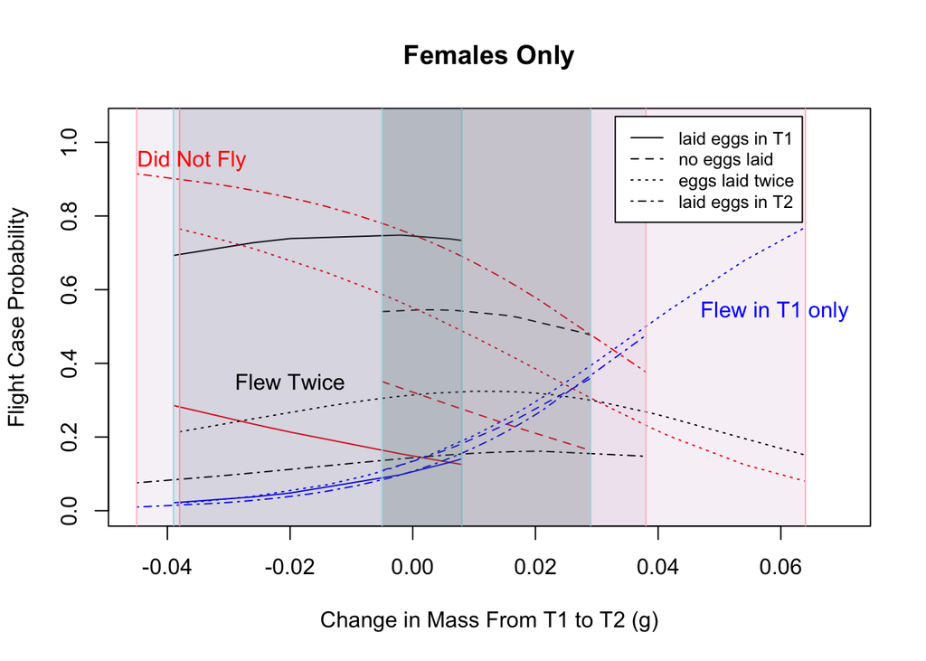

- Eggs laid twice: most likely to not fly unless gain more than about 0.025 g mass and then fly only in T1 (largest mass change)
- Eggs laid in T2: most likely to not fly (2nd widest mass change)
- Eggs laid only in T1: most likely to fly twice (mostly only lost mass)
- Eggs not laid: most likely to fly twice always (smallest mass change and mostly only gained about 0.030 g)

**wing2body**

**Baseline**

```r
df <- d %>%
  filter(!is.na(egg_case), !is.na(mass_diff), !is.na(flew_diff), !is.na(wing2body), sex_c == 1)

df <- df[with(df, order(mass_diff)),]

n_tfemales = nrow(df)

df$flight_case <- relevel(as.factor(df$flight_case), ref = "0")
```

```r
data <- data.frame(R = df$flight_case,
         A = df$egg_case,
         B = df$mass_diff,
         C = df$wing2body)
source("src/compare_models.R")
model_comparisonsAIC("src/generic multinomial models- multinom 1RF + 3 FF.R") # strange error...
```

```
##        [,1]      [,2]      [,3]      [,4]      [,5]       [,6]
## AICs   165.9791  167.0497  168.793   169.6042  169.9652   169.9733
## models 7         4         12        11        13         8
## probs  0.4170701 0.2441983 0.1021376 0.0680834 0.05683876 0.05661042
##
## m7   multinom(formula = R ~ A + B + C, data = data, trace = FALSE)
## m4   multinom(formula = R ~ A + B, data = data, trace = FALSE)
## m12  multinom(formula = R ~ A * C + B, data = data, trace = FALSE)
## m11  multinom(formula = R ~ A * B + C, data = data, trace = FALSE)
## m13  multinom(formula = R ~ B * C + A, data = data, trace = FALSE)
## m8   multinom(formula = R ~ A * B, data = data, trace = FALSE)
```

```r
anova(m4, m7, test="Chisq") # adding wing2body does not include fit
```

```
## Likelihood ratio tests of Multinomial Models
##
## Response: R
##       Model Resid. df Resid. Dev   Test    Df LR stat.    Pr(Chi)
## 1     A + B       180   155.0497
## 2 A + B + C       178   149.9791 1 vs 2     2 5.070548 0.07924002
```

```r
anova(m7, m12, test="Chisq") # Adding A*C does not improve fit
```

```
## Likelihood ratio tests of Multinomial Models
##
## Response: R
##       Model Resid. df Resid. Dev   Test    Df LR stat.   Pr(Chi)
## 1 A + B + C       178   149.9791
## 2 A * C + B       176   148.7930 1 vs 2     2 1.186134 0.5526299
```

```r
anova(m7, m11, test="Chisq")
```

```
## Likelihood ratio tests of Multinomial Models
##
## Response: R
##       Model Resid. df Resid. Dev   Test    Df  LR stat.   Pr(Chi)
## 1 A + B + C       178   149.9791
## 2 A * B + C       176   149.6042 1 vs 2     2 0.3749583 0.8290464
```

```r
anova(m7, m13, test="Chisq")
```

```
## Likelihood ratio tests of Multinomial Models
##
## Response: R
##       Model Resid. df Resid. Dev   Test    Df   LR stat.   Pr(Chi)
## 1 A + B + C       178   149.9791
## 2 B * C + A       176   149.9652 1 vs 2     2 0.01392852 0.9930599
```

```r
anova(m4, m8, test="Chisq") # Adding A*B does not improve fit
```

```
## Likelihood ratio tests of Multinomial Models
##
## Response: R
##   Model Resid. df Resid. Dev   Test    Df LR stat.   Pr(Chi)
## 1 A + B       180   155.0497
## 2 A * B       178   153.9733 1 vs 2     2 1.076425 0.5837908
```

### Encodings

| Delta Flight Response Key Event | Delta Flight Response Key Encoding |
| --- | --- |
| flew in both trials | 2 |
| flew in T2 only | 1 |
| flew in neither trials | 0 |
| flew in T1 only | -1 |

| Delta Mass Key Event | Delta Mass Key Sign |
| --- | --- |
| gained mass from T1 to T2 | pos |
| no mass change between trails | 0 |
| lost mass from T1 to T2 | neg |

| Host Plant Key Host | Host Plant Key Encoding |
| --- | --- |
| Golden Rain Tree (GRT) | 1 |
| Balloon Vine (BV) | -1 |

**Females Only**

| Delta Flight Response Key Event | Delta Flight Response Key Encoding |
| --- | --- |
| flew in both trials | 2 |
| flew in neither trial | 0 |
| flew in T1 only | -1 |

| Delta Egg Response Key Event | Delta Egg Response Key Encoding |
| --- | --- |
| laid eggs in both trials | 2 |
| laid eggs in T2 only | 1 |
| laid eggs in neither trials | 0 |
| laid eggs in T1 only | -1 |

### Summary

**flight case ~ mass diff**

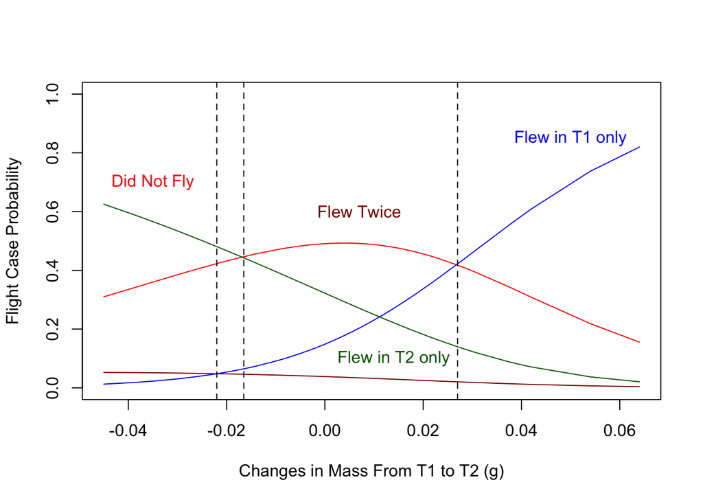

**flight case ~ mass per**

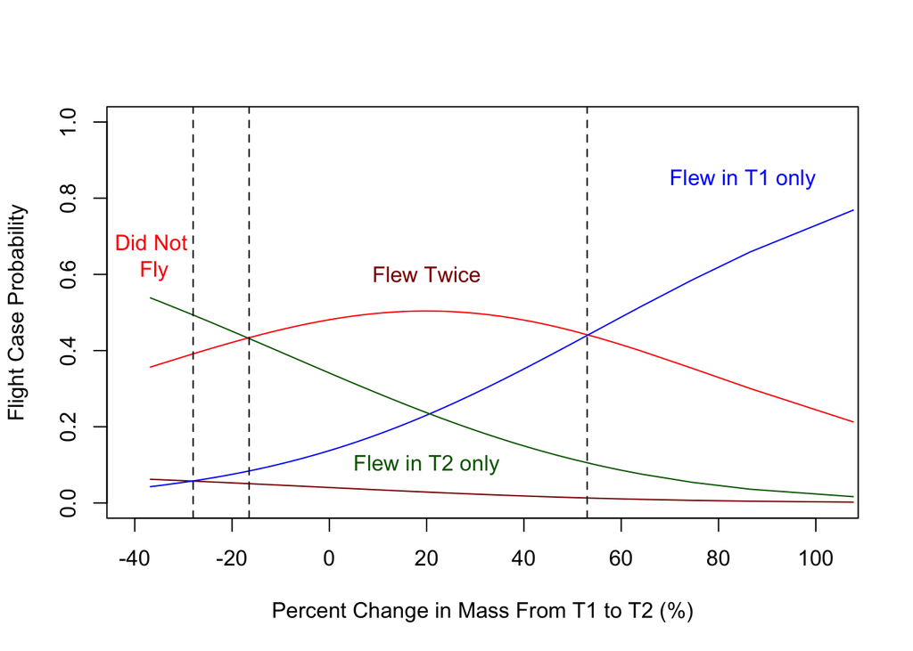

**flight case ~ mass per and sex**

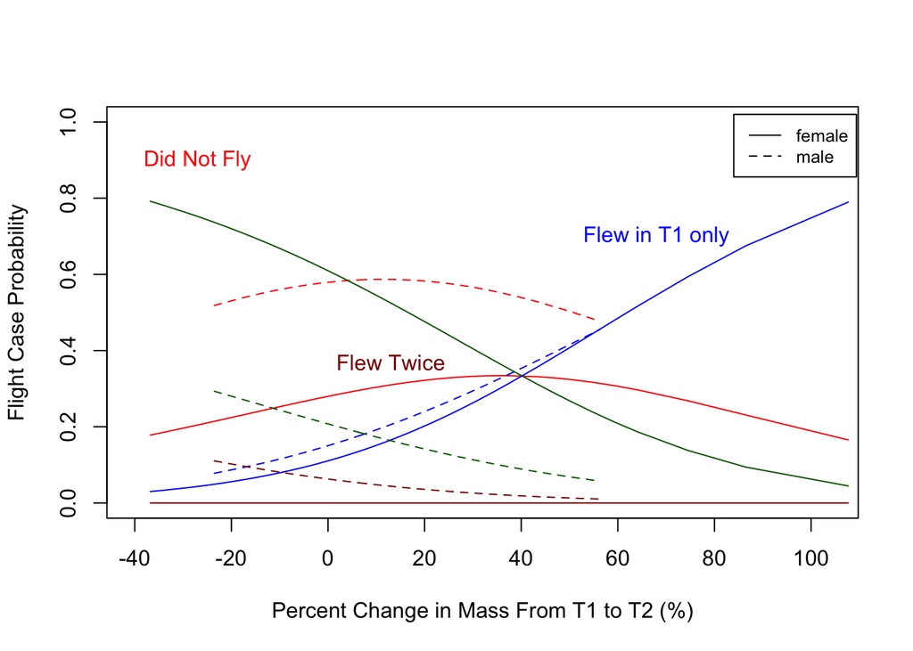

**wing2body**

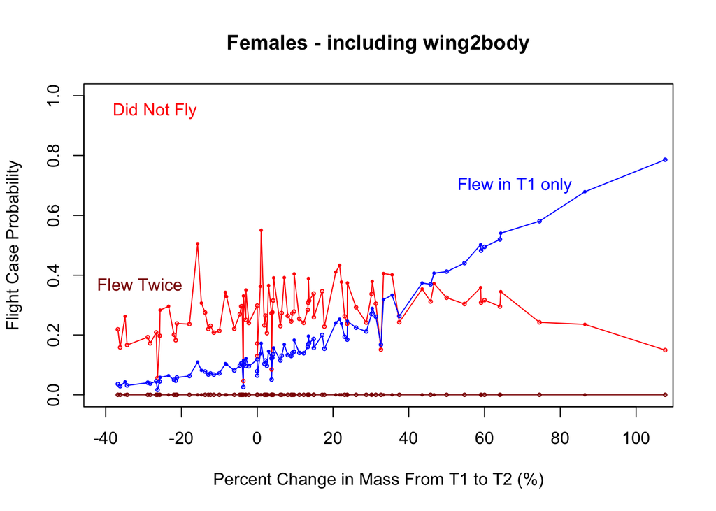

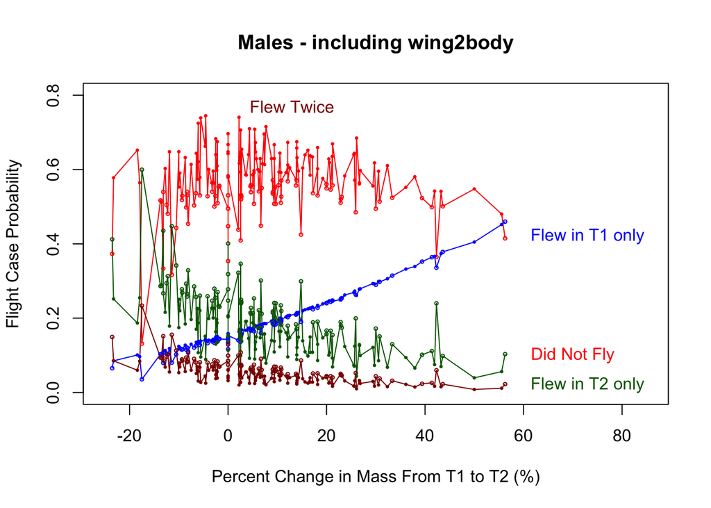

**females only**

**flight case ~ mass diff and egg case**

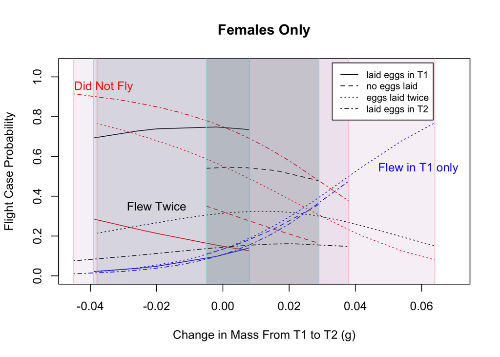

### Questions

- Egg case and egg diff not factors. Not sure how to work around this problem.
- Subtracting equations when p values are not significant…is that possible? What are the implications if it is?
- Animate plots?
- For Fall season some bugs were tested more than 2 times (up to four times), but which to pull from and from which experiments?